# Joining Data with Pandas

Lecturers: Richie Cotton, Maggie Matsui

It is recommended that you take the course [**Data Manipulation with Pandas** prior to this course.](https://quannguyeniu.github.io/DataCamp/Python/Data_Manipulation_Pandas.html)

# 1 Course Description

Being able to combine and work with multiple datasets is an essential skill for any aspiring Data Scientist. pandas is a crucial cornerstone of the Python data science ecosystem, with Stack Overflow recording 5 million views for pandas questions. Learn to handle multiple DataFrames by combining, organizing, joining, and reshaping them using pandas. You’ll work with datasets from the World Bank and the City Of Chicago. You will finish the course with a solid skillset for data-joining in pandas.

Course materials can be found [**here**.](https://github.com/QuanNguyenIU/QuanNguyenIU.github.io/tree/main/DataCamp/Python/Joining%20Data%20with%20Pandas)

# 2 Data Merging Basics

Learn how you can merge disparate data using inner joins. By combining information from multiple sources you’ll uncover compelling insights that may have previously been hidden. You’ll also learn how the relationship between those sources, such as one-to-one or one-to-many, can affect your result.

## 2.1 Lecture: Inner join

[video not shown]

## 2.2 Your first inner join

You have been tasked with figuring out what the most popular types of fuel used in Chicago taxis are. To complete the analysis, you need to merge the [**taxi_owners** and [**taxi_veh** tables together on the vid column. You can then use the merged table along with the .value_counts() method to find the most common fuel_type.](https://raw.githubusercontent.com/QuanNguyenIU/QuanNguyenIU.github.io/main/DataCamp/Python/Joining%20Data%20with%20Pandas/taxi_veh.csv)](https://raw.githubusercontent.com/QuanNguyenIU/QuanNguyenIU.github.io/main/DataCamp/Python/Joining%20Data%20with%20Pandas/taxi_owners.csv)

```python
import pandas as pd
url = 'https://raw.githubusercontent.com/QuanNguyenIU/QuanNguyenIU.github.io/main/DataCamp/Python/Joining%20Data%20with%20Pandas/taxi_owners.csv'
taxi_owners = pd.read_csv(url)
url = 'https://raw.githubusercontent.com/QuanNguyenIU/QuanNguyenIU.github.io/main/DataCamp/Python/Joining%20Data%20with%20Pandas/taxi_veh.csv'
taxi_veh = pd.read_csv(url)

# Merge the taxi_owners and taxi_veh tables
taxi_own_veh = taxi_owners.merge(taxi_veh,on='vid')

# Print the column names of the taxi_own_veh
print(taxi_own_veh.columns)
```

```
## Index(['rid', 'vid', 'owner_x', 'address', 'zip', 'make', 'model', 'year',
##        'fuel_type', 'owner_y'],
##       dtype='object')
```

```python
# Merge the taxi_owners and taxi_veh tables setting a suffix
taxi_own_veh = taxi_owners.merge(taxi_veh, on='vid',suffixes = ['_own','_veh'])

# Print the column names of taxi_own_veh
print(taxi_own_veh.columns)
```

```
## Index(['rid', 'vid', 'owner_own', 'address', 'zip', 'make', 'model', 'year',
##        'fuel_type', 'owner_veh'],
##       dtype='object')
```

```python
# Merge the taxi_owners and taxi_veh tables setting a suffix
taxi_own_veh = taxi_owners.merge(taxi_veh, on='vid', suffixes=('_own','_veh'))

# Print the value_counts to find the most popular fuel_type
print(taxi_own_veh['fuel_type'].value_counts())
```

```
## fuel_type
## HYBRID                    2792
## GASOLINE                   611
## FLEX FUEL                   89
## COMPRESSED NATURAL GAS      27
## Name: count, dtype: int64
```

Bravo! You correctly merged the two tables together and found out that the most common fuel type for taxis in Chicago are hybrids.

## 2.3 Inner joins and number of rows returned

All of the merges you have studied to this point are called inner joins. It is necessary to understand that inner joins only return the rows with matching values in both tables. You will explore this further by reviewing the merge between the [**wards** and [**census** tables, then comparing it to merges of copies of these tables that are slightly altered, named [**wards_altered**, and [**census_altered**. The first row of the wards column has been changed in the altered tables. You will examine how this affects the merge between them. The tables have been loaded for you.](https://raw.githubusercontent.com/QuanNguyenIU/QuanNguyenIU.github.io/main/DataCamp/Python/Joining%20Data%20with%20Pandas/census_altered.csv)](https://raw.githubusercontent.com/QuanNguyenIU/QuanNguyenIU.github.io/main/DataCamp/Python/Joining%20Data%20with%20Pandas/wards_altered.csv)](https://raw.githubusercontent.com/QuanNguyenIU/QuanNguyenIU.github.io/main/DataCamp/Python/Joining%20Data%20with%20Pandas/census.csv)](https://raw.githubusercontent.com/QuanNguyenIU/QuanNguyenIU.github.io/main/DataCamp/Python/Joining%20Data%20with%20Pandas/wards.csv)

For this exercise, it is important to know that the wards and census tables start with 50 rows.

```python
url = 'https://raw.githubusercontent.com/QuanNguyenIU/QuanNguyenIU.github.io/main/DataCamp/Python/Joining%20Data%20with%20Pandas/wards.csv'
wards = pd.read_csv(url)
url = 'https://raw.githubusercontent.com/QuanNguyenIU/QuanNguyenIU.github.io/main/DataCamp/Python/Joining%20Data%20with%20Pandas/census.csv'
census = pd.read_csv(url)
# Merge the wards and census tables on the ward column
wards_census = wards.merge(census,on='ward')

# Print the shape of wards_census
print('wards_census table shape:', wards_census.shape)
```

```
## wards_census table shape: (50, 9)
```

```python
url = 'https://raw.githubusercontent.com/QuanNguyenIU/QuanNguyenIU.github.io/main/DataCamp/Python/Joining%20Data%20with%20Pandas/wards_altered.csv'
wards_altered = pd.read_csv(url)
# Print the first few rows of the wards_altered table to view the change
print(wards_altered[['ward']].head())
```

```
##    ward
## 0    61
## 1     2
## 2     3
## 3     4
## 4     5
```

```python
# Merge the wards_altered and census tables on the ward column
wards_altered_census = wards_altered.merge(census, on='ward')

# Print the shape of wards_altered_census
print('wards_altered_census table shape:', wards_altered_census.shape)
```

```
## wards_altered_census table shape: (49, 9)
```

```python
url = 'https://raw.githubusercontent.com/QuanNguyenIU/QuanNguyenIU.github.io/main/DataCamp/Python/Joining%20Data%20with%20Pandas/census_altered.csv'
census_altered = pd.read_csv(url)
# Print the first few rows of the census_altered table to view the change
print(census_altered[['ward']].head())
```

```
##    ward
## 0   NaN
## 1   2.0
## 2   3.0
## 3   4.0
## 4   5.0
```

```python
# Merge the wards and census_altered tables on the ward column
wards_census_altered = wards.merge(census_altered, on='ward')

# Print the shape of wards_census_altered
print('wards_census_altered table shape:', wards_census_altered.shape)
```

```
## wards_census_altered table shape: (49, 9)
```

In step 1, the .merge() returned a table with the same number of rows as the original wards table. However, in steps 2 and 3, using the altered tables with the altered first row of the ward column, the number of returned rows was fewer. There was not a matching value in the ward column of the other table. Remember that .merge() only returns rows where the values match in both tables.

## 2.4 Lecture: One-to-many relationships

[video not shown]

## 2.5 One-to-many merge

A business may have one or multiple owners. In this exercise, you will continue to gain experience with one-to-many merges by merging a table of business owners, called [**biz_owners**, to the [**licenses** table. Recall from the video lesson, with a one-to-many relationship, a row in the left table may be repeated if it is related to multiple rows in the right table. In this lesson, you will explore this further by finding out what is the most common business owner title (i.e., secretary, CEO, or vice president).](https://raw.githubusercontent.com/QuanNguyenIU/QuanNguyenIU.github.io/main/DataCamp/Python/Joining%20Data%20with%20Pandas/licenses.csv)](https://raw.githubusercontent.com/QuanNguyenIU/QuanNguyenIU.github.io/main/DataCamp/Python/Joining%20Data%20with%20Pandas/biz_owners.csv)

```python
url = 'https://raw.githubusercontent.com/QuanNguyenIU/QuanNguyenIU.github.io/main/DataCamp/Python/Joining%20Data%20with%20Pandas/licenses.csv'
licenses = pd.read_csv(url)
url = 'https://raw.githubusercontent.com/QuanNguyenIU/QuanNguyenIU.github.io/main/DataCamp/Python/Joining%20Data%20with%20Pandas/biz_owners.csv'
biz_owners = pd.read_csv(url)
# Merge the licenses and biz_owners table on account
licenses_owners = licenses.merge(biz_owners, on='account')

# Group the results by title then count the number of accounts
counted_df = licenses_owners.groupby('title').agg({'account':'count'})

# Sort the counted_df in desending order
sorted_df = counted_df.sort_values(by='account',ascending=False)

# Use .head() method to print the first few rows of sorted_df
print(sorted_df.head())
```

```
##                  account
## title
## PRESIDENT           6259
## SECRETARY           5205
## SOLE PROPRIETOR     1658
## OTHER               1200
## VICE PRESIDENT       970
```

Wonderful! After merging the tables together, you counted the number of repeated rows with the combination of .groupby() and .agg() statements. You see that president, followed by secretary, are the most common business owner titles.

## 2.6 Lecture: Merging multiple DataFrames

[video not shown]

## 2.7 Total riders in a month

Your goal is to find the total number of rides provided to passengers passing through the Wilson station (station_name == ‘Wilson’) when riding Chicago’s public transportation system on weekdays (day_type == ‘Weekday’) in July (month == 7). Luckily, Chicago provides this detailed data, but it is in three different tables. You will work on merging these tables together to answer the question. This data is different from the business related data you have seen so far, but all the information you need to answer the question is provided.

The [**cal**, [**ridership**, and [**stations** DataFrames have been loaded for you. The relationship between the tables can be seen in the diagram below.](https://raw.githubusercontent.com/QuanNguyenIU/QuanNguyenIU.github.io/main/DataCamp/Python/Joining%20Data%20with%20Pandas/stations.csv)](https://raw.githubusercontent.com/QuanNguyenIU/QuanNguyenIU.github.io/main/DataCamp/Python/Joining%20Data%20with%20Pandas/ridership.csv)](https://raw.githubusercontent.com/QuanNguyenIU/QuanNguyenIU.github.io/main/DataCamp/Python/Joining%20Data%20with%20Pandas/cal.csv)

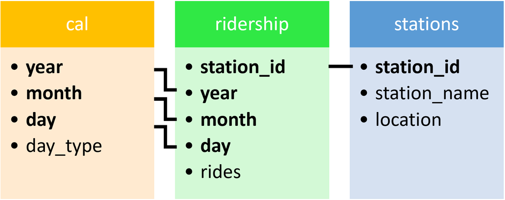

```python
url = 'https://raw.githubusercontent.com/QuanNguyenIU/QuanNguyenIU.github.io/main/DataCamp/Python/Joining%20Data%20with%20Pandas/ridership.csv'
ridership = pd.read_csv(url)
url = 'https://raw.githubusercontent.com/QuanNguyenIU/QuanNguyenIU.github.io/main/DataCamp/Python/Joining%20Data%20with%20Pandas/cal.csv'
cal = pd.read_csv(url)
url = 'https://raw.githubusercontent.com/QuanNguyenIU/QuanNguyenIU.github.io/main/DataCamp/Python/Joining%20Data%20with%20Pandas/stations.csv'
stations = pd.read_csv(url)
# Merge the ridership, cal, and stations tables
ridership_cal_stations = ridership.merge(cal, on=['year','month','day']) \
                            .merge(stations, on='station_id')

# Create a filter to filter ridership_cal_stations
filter_criteria = ((ridership_cal_stations['month'] == 7)
                   & (ridership_cal_stations['day_type'] == 'Weekday')
                   & (ridership_cal_stations['station_name'] == 'Wilson'))

# Use .loc and the filter to select for rides
print(ridership_cal_stations.loc[filter_criteria, 'rides'].sum())
```

```
## 140005
```

Awesome work! You merged three DataFrames together, including merging two tables on multiple columns. Once the tables were merged, you filtered and selected just like any other DataFrame. Finally, you found out that the Wilson station had 140,005 riders during weekdays in July.

## 2.8 Three table merge

To solidify the concept of a three DataFrame merge, practice another exercise. A reasonable extension of our review of Chicago business data would include looking at demographics information about the neighborhoods where the businesses are. A table with the median income by zip code has been provided to you. You will merge the licenses and wards tables with this new income-by-zip-code table called [**zip_demo**.](https://raw.githubusercontent.com/QuanNguyenIU/QuanNguyenIU.github.io/main/DataCamp/Python/Joining%20Data%20with%20Pandas/zip_demo.csv)

```python
url = 'https://raw.githubusercontent.com/QuanNguyenIU/QuanNguyenIU.github.io/main/DataCamp/Python/Joining%20Data%20with%20Pandas/zip_demo.csv'
zip_demo = pd.read_csv(url)
# Merge licenses and zip_demo, on zip; and merge the wards on ward
licenses_zip_ward = licenses.merge(zip_demo,on='zip') \
                        .merge(wards,on='ward')

# Print the results by alderman and show median income
print(licenses_zip_ward.groupby('alderman').agg({'income':'median'}))
```

```
##                                  income
## alderman
## "Daniel ""Danny"" Solis"        41226.0
## "Milagros ""Milly"" Santiago"   41307.0
## "Proco ""Joe"" Moreno"          87143.0
## Ameya Pawar                     66246.0
## Anthony A. Beale                38206.0
## Anthony V. Napolitano           82226.0
## Ariel E. Reyboras               41307.0
## Brendan Reilly                 110215.0
## Brian Hopkins                   87143.0
## Carlos Ramirez-Rosa             66246.0
## Carrie M. Austin                38206.0
## Chris Taliaferro                55566.0
## David H. Moore                  33304.0
## Deborah Mell                    66246.0
## Debra L. Silverstein            50554.0
## Derrick G. Curtis               65770.0
## Edward M. Burke                 42335.0
## Emma M. Mitts                   36283.0
## George Cardenas                 33959.0
## Gilbert Villegas                41307.0
## Gregory I. Mitchell             24941.0
## Harry Osterman                  45442.0
## Howard B. Brookins, Jr.         33304.0
## James Cappleman                 79565.0
## Jason C. Ervin                  41226.0
## Joe Moore                       39163.0
## John S. Arena                   70122.0
## Leslie A. Hairston              28024.0
## Margaret Laurino                70122.0
## Marty Quinn                     67045.0
## Matthew J. O\'Shea              59488.0
## Michael R. Zalewski             42335.0
## Michael Scott, Jr.              31445.0
## Michelle A. Harris              32558.0
## Michelle Smith                 100116.0
## Nicholas Sposato                62223.0
## Pat Dowell                      46340.0
## Patrick Daley Thompson          41226.0
## Patrick J. O\'Connor            50554.0
## Raymond A. Lopez                33959.0
## Ricardo Munoz                   31445.0
## Roberto Maldonado               68223.0
## Roderick T. Sawyer              32558.0
## Scott Waguespack                68223.0
## Susan Sadlowski Garza           38417.0
## Tom Tunney                      88708.0
## Toni L. Foulkes                 27573.0
## Walter Burnett, Jr.             87143.0
## William D. Burns               107811.0
## Willie B. Cochran               28024.0
```

## 2.9 One-to-many merge with multiple tables

In this exercise, assume that you are looking to start a business in the city of Chicago. Your perfect idea is to start a company that uses goats to mow the lawn for other businesses. However, you have to choose a location in the city to put your goat farm. You need a location with a great deal of space and relatively few businesses and people around to avoid complaints about the smell. You will need to merge three tables to help you choose your location. The [**land_use** table has info on the percentage of vacant land by city ward. The census table has population by ward, and the licenses table lists businesses by ward.](https://raw.githubusercontent.com/QuanNguyenIU/QuanNguyenIU.github.io/main/DataCamp/Python/Joining%20Data%20with%20Pandas/land_use.csv)

```python
url = 'https://raw.githubusercontent.com/QuanNguyenIU/QuanNguyenIU.github.io/main/DataCamp/Python/Joining%20Data%20with%20Pandas/land_use.csv'
land_use = pd.read_csv(url)

# Merge land_use and census and merge result with licenses including suffixes
land_cen_lic = land_use.merge(census, on='ward') \
                    .merge(licenses, on='ward', suffixes=('_cen','_lic'))

# Group by ward, pop_2010, and vacant, then count the # of accounts
pop_vac_lic = land_cen_lic.groupby(['ward','pop_2010','vacant'],
                                   as_index=False).agg({'account':'count'})

# Sort pop_vac_lic and print the results
sorted_pop_vac_lic = pop_vac_lic.sort_values(['vacant','account','pop_2010'],
                                             ascending=[False,True,True])

# Print the top few rows of sorted_pop_vac_lic
print(sorted_pop_vac_lic.head())
```

```
##     ward  pop_2010  vacant  account
## 6      7     51581      19       80
## 19    20     52372      15      123
## 9     10     51535      14      130
## 23    24     54909      13       98
## 15    16     51954      13      156
```

Great job putting your new skills into action. You merged multiple tables with varying relationships and added suffixes to make your column names clearer. Using your skills, you were able to pull together information from different tables to see that the 7th ward would be a good place to build your goat farm!

# 3 Merging Tables With Different Join Types

Take your knowledge of joins to the next level. In this chapter, you’ll work with TMDb movie data as you learn about left, right, and outer joins. You’ll also discover how to merge a table to itself and merge on a DataFrame index.

## 3.1 Lecture: Left join

[video not shown]

## 3.2 Counting missing rows with left join

The Movie Database is supported by volunteers going out into the world, collecting data, and entering it into the database. This includes financial data, such as movie budget and revenue. If you wanted to know which movies are still missing data, you could use a left join to identify them. Practice using a left join by merging the [**movies** table and the [**financials** table.](https://raw.githubusercontent.com/QuanNguyenIU/QuanNguyenIU.github.io/main/DataCamp/Python/Joining%20Data%20with%20Pandas/financials.csv)](https://raw.githubusercontent.com/QuanNguyenIU/QuanNguyenIU.github.io/main/DataCamp/Python/Joining%20Data%20with%20Pandas/movies.csv)

```python
url = 'https://raw.githubusercontent.com/QuanNguyenIU/QuanNguyenIU.github.io/main/DataCamp/Python/Joining%20Data%20with%20Pandas/movies.csv'
movies = pd.read_csv(url)
url = 'https://raw.githubusercontent.com/QuanNguyenIU/QuanNguyenIU.github.io/main/DataCamp/Python/Joining%20Data%20with%20Pandas/financials.csv'
financials = pd.read_csv(url)

# Merge the movies table with the financials table with a left join
movies_financials = movies.merge(financials, on='id', how='left')

# Count the number of rows in the budget column that are missing
number_of_missing_fin = movies_financials['budget'].isnull().sum()

# Print the number of movies missing financials
print(number_of_missing_fin)
```

```
## 1574
```

Great job! You used a left join to find out which rows in the financials table were missing data. When performing a left join, the .merge() method returns a row full of null values for columns in the right table if the key column does not have a matching value in both tables. We see that there are at least 1,500 rows missing data. Wow! That sounds like a lot of work.

## 3.3 Enriching a dataset

Setting how=‘left’ with the .merge()method is a useful technique for enriching or enhancing a dataset with additional information from a different table. In this exercise, you will start off with a [**sample of movie data** from the movie series Toy Story. Your goal is to enrich this data by adding the [**marketing tag line** for each movie. You will compare the results of a left join versus an inner join.](https://raw.githubusercontent.com/QuanNguyenIU/QuanNguyenIU.github.io/main/DataCamp/Python/Joining%20Data%20with%20Pandas/taglines.csv)](https://raw.githubusercontent.com/QuanNguyenIU/QuanNguyenIU.github.io/main/DataCamp/Python/Joining%20Data%20with%20Pandas/toy_story.csv)

```python
url = 'https://raw.githubusercontent.com/QuanNguyenIU/QuanNguyenIU.github.io/main/DataCamp/Python/Joining%20Data%20with%20Pandas/toy_story.csv'
toy_story = pd.read_csv(url)
url = 'https://raw.githubusercontent.com/QuanNguyenIU/QuanNguyenIU.github.io/main/DataCamp/Python/Joining%20Data%20with%20Pandas/taglines.csv'
taglines = pd.read_csv(url)

# Merge the toy_story and taglines tables with a left join
toystory_tag = toy_story.merge(taglines,on='id',how='left')

# Print the rows and shape of toystory_tag
print(toystory_tag)
```

```
##       id        title  popularity release_date                   tagline
## 0  10193  Toy Story 3   59.995418   2010-06-16  No toy gets left behind.
## 1    863  Toy Story 2   73.575118   1999-10-30        The toys are back!
## 2    862    Toy Story   73.640445   1995-10-30                       NaN
```

```python
print(toystory_tag.shape)
```

```
## (3, 5)
```

```python
# Merge the toy_story and taglines tables with a inner join
toystory_tag = toy_story.merge(taglines,on='id')

# Print the rows and shape of toystory_tag
print(toystory_tag)
```

```
##       id        title  popularity release_date                   tagline
## 0  10193  Toy Story 3   59.995418   2010-06-16  No toy gets left behind.
## 1    863  Toy Story 2   73.575118   1999-10-30        The toys are back!
```

```python
print(toystory_tag.shape)
```

```
## (2, 5)
```

If your goal is to enhance or enrich a dataset, then you do not want to lose any of your original data. A left join will do that by returning all of the rows of your left table, while using an inner join may result in lost data if it does not exist in both tables.

## 3.4 Lecture: Other joins

[video not shown]

## 3.5 Right join to find unique movies

Most of the recent big-budget science fiction movies can also be classified as action movies. You are given a table of science fiction movies called [**scifi_movies** and another table of action movies called [**action_movies**. Your goal is to find which movies are considered only science fiction movies. Once you have this table, you can merge the movies table in to see the movie names.](https://raw.githubusercontent.com/QuanNguyenIU/QuanNguyenIU.github.io/main/DataCamp/Python/Joining%20Data%20with%20Pandas/action_movies.csv)](https://raw.githubusercontent.com/QuanNguyenIU/QuanNguyenIU.github.io/main/DataCamp/Python/Joining%20Data%20with%20Pandas/scifi_movies.csv)

```python
url = 'https://raw.githubusercontent.com/QuanNguyenIU/QuanNguyenIU.github.io/main/DataCamp/Python/Joining%20Data%20with%20Pandas/action_movies.csv'
action_movies = pd.read_csv(url)
url = 'https://raw.githubusercontent.com/QuanNguyenIU/QuanNguyenIU.github.io/main/DataCamp/Python/Joining%20Data%20with%20Pandas/scifi_movies.csv'
scifi_movies = pd.read_csv(url)

# Merge action_movies to scifi_movies with right join
action_scifi = action_movies.merge(scifi_movies, on = 'movie_id', how = 'right', suffixes = ['_act', '_sci'])

# Print the first few rows of action_scifi to see the structure
print(action_scifi.head())
```

```
##    movie_id genre_act        genre_sci
## 0        11    Action  Science Fiction
## 1        18    Action  Science Fiction
## 2        19       NaN  Science Fiction
## 3        38       NaN  Science Fiction
## 4        62       NaN  Science Fiction
```

```python
# From action_scifi, select only the rows where the genre_act column is null
scifi_only = action_scifi[action_scifi['genre_act'].isnull()]

# Merge the movies and scifi_only tables with an inner join
movies_and_scifi_only = movies.merge(scifi_only, left_on = 'id', right_on = 'movie_id', how = 'inner')

# Print the first few rows and shape of movies_and_scifi_only
print(movies_and_scifi_only.head())
```

```
##       id                         title  ...  genre_act        genre_sci
## 0  18841  The Lost Skeleton of Cadavra  ...        NaN  Science Fiction
## 1  26672     The Thief and the Cobbler  ...        NaN  Science Fiction
## 2  15301      Twilight Zone: The Movie  ...        NaN  Science Fiction
## 3   8452                   The 6th Day  ...        NaN  Science Fiction
## 4   1649    Bill & Ted's Bogus Journey  ...        NaN  Science Fiction
##
## [5 rows x 7 columns]
```

```python
print(movies_and_scifi_only.shape)
```

```
## (258, 7)
```

## 3.6 Popular genres with right join

What are the genres of the most popular movies? To answer this question, you need to merge data from the **movies** and [**movie_to_genres** tables. In a table called [**pop_movies**, the top 10 most popular movies in the **movies** table have been selected. To ensure that you are analyzing all of the popular movies, merge it with the **movie_to_genres** table using a right join. To complete your analysis, count the number of different genres. Also, the two tables can be merged by the movie ID. However, in **pop_movies** that column is called **id**, and in **movie_to_genres** it’s called **movie_id**.](https://raw.githubusercontent.com/QuanNguyenIU/QuanNguyenIU.github.io/main/DataCamp/Python/Joining%20Data%20with%20Pandas/pop_movies.csv)](https://raw.githubusercontent.com/QuanNguyenIU/QuanNguyenIU.github.io/main/DataCamp/Python/Joining%20Data%20with%20Pandas/movie_to_genres.csv)

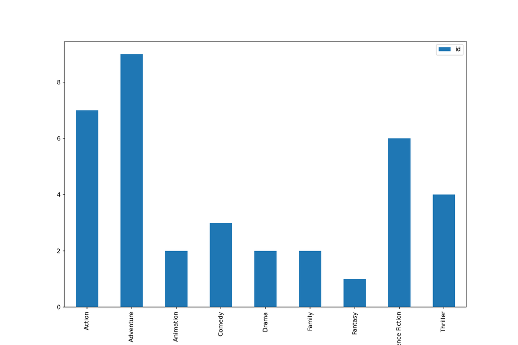

```python
url = 'https://raw.githubusercontent.com/QuanNguyenIU/QuanNguyenIU.github.io/main/DataCamp/Python/Joining%20Data%20with%20Pandas/movie_to_genres.csv'
movie_to_genres = pd.read_csv(url)
url = 'https://raw.githubusercontent.com/QuanNguyenIU/QuanNguyenIU.github.io/main/DataCamp/Python/Joining%20Data%20with%20Pandas/pop_movies.csv'
pop_movies = pd.read_csv(url)

# Use right join to merge the movie_to_genres and pop_movies tables
genres_movies = movie_to_genres.merge(pop_movies, how='right',
                                      left_on='movie_id',
                                      right_on='id')

# Count the number of genres
genre_count = genres_movies.groupby('genre').agg({'id':'count'})

# Plot a bar chart of the genre_count
import matplotlib.pyplot as plt
genre_count.plot(kind='bar')
plt.show()
```

The right join ensured that you were analyzing all of the **pop_movies**. You see from the results that adventure and action are the most popular genres.

## 3.7 Using outer join to select actors

One cool aspect of using an outer join is that, because it returns all rows from both merged tables and null where they do not match, you can use it to find rows that do not have a match in the other table. To try for yourself, you have been given two tables with a list of actors from two popular movies: [**Iron Man 1** and [**Iron Man 2**. Most of the actors played in both movies. Use an outer join to find actors who did not act in both movies.](https://raw.githubusercontent.com/QuanNguyenIU/QuanNguyenIU.github.io/main/DataCamp/Python/Joining%20Data%20with%20Pandas/iron_2_actors.csv)](https://raw.githubusercontent.com/QuanNguyenIU/QuanNguyenIU.github.io/main/DataCamp/Python/Joining%20Data%20with%20Pandas/iron_1_actors.csv)

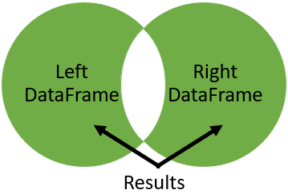

```python
url = 'https://raw.githubusercontent.com/QuanNguyenIU/QuanNguyenIU.github.io/main/DataCamp/Python/Joining%20Data%20with%20Pandas/iron_1_actors.csv'
iron_1_actors = pd.read_csv(url)
url = 'https://raw.githubusercontent.com/QuanNguyenIU/QuanNguyenIU.github.io/main/DataCamp/Python/Joining%20Data%20with%20Pandas/iron_2_actors.csv'
iron_2_actors = pd.read_csv(url)
# Merge iron_1_actors to iron_2_actors on id with outer join using suffixes
iron_1_and_2 = iron_1_actors.merge(iron_2_actors,
                                     how='outer',
                                     on='id',
                                     suffixes=['_1','_2'])

# Create an index that returns true if name_1 or name_2 are null
m = ((iron_1_and_2['name_1'].isnull()) |
     (iron_1_and_2['name_2'].isnull()))

# Print the first few rows of iron_1_and_2
print(iron_1_and_2[m].head())
```

```
##                    character_1  ...              name_2
## 0  Obadiah Stane / Iron Monger  ...                 NaN
## 1                          NaN  ...  Scarlett Johansson
## 2                          NaN  ...         Don Cheadle
## 4                          NaN  ...       Mickey Rourke
## 7                          NaN  ...        Sam Rockwell
##
## [5 rows x 5 columns]
```

## 3.8 Lecture: Merging a table to itself

[video not shown]

## 3.9 Self join

Merging a table to itself can be useful when you want to compare values in a column to other values in the same column. In this exercise, you will practice this by creating a table that for each movie will list the movie director and a member of the crew on one row. You have been given a table called [**crews**, which has columns id, job, and name. First, merge the table to itself using the movie ID. This merge will give you a larger table where for each movie, every job is matched against each other. Then select only those rows with a director in the left table, and avoid having a row where the director’s job is listed in both the left and right tables. This filtering will remove job combinations that aren’t with the director.](https://raw.githubusercontent.com/QuanNguyenIU/QuanNguyenIU.github.io/main/DataCamp/Python/Joining%20Data%20with%20Pandas/crews.csv)

```python
url = 'https://raw.githubusercontent.com/QuanNguyenIU/QuanNguyenIU.github.io/main/DataCamp/Python/Joining%20Data%20with%20Pandas/crews.csv'
crews = pd.read_csv(url)

# Merge the crews table to itself
crews_self_merged = crews.merge(crews, on='id', how='inner',
                                suffixes=('_dir','_crew'))

# Create a boolean index to select the appropriate rows
boolean_filter = ((crews_self_merged['job_dir'] == 'Director') &
                  (crews_self_merged['job_crew'] != 'Director'))
direct_crews = crews_self_merged[boolean_filter]

# Print the first few rows of direct_crews
print(direct_crews.head())
```

```
##         id department_dir  ...        job_crew          name_crew
## 156  19995      Directing  ...          Editor  Stephen E. Rivkin
## 157  19995      Directing  ...  Sound Designer  Christopher Boyes
## 158  19995      Directing  ...         Casting          Mali Finn
## 160  19995      Directing  ...          Writer      James Cameron
## 161  19995      Directing  ...    Set Designer    Richard F. Mays
##
## [5 rows x 7 columns]
```

By merging the table to itself, you compared the value of the **director** from the jobs column to other values from the jobs column. With the output, you can quickly see different movie directors and the people they worked with in the same movie.

## 3.10 Lecture: Merging on indexes

[video not shown]

## 3.11 Index merge for movie ratings

To practice merging on indexes, you will merge **movies** and a table called [**ratings** that holds info about movie ratings. Ensure that your merge returns all rows from the movies table, and only matching rows from the ratings table.](https://raw.githubusercontent.com/QuanNguyenIU/QuanNguyenIU.github.io/main/DataCamp/Python/Joining%20Data%20with%20Pandas/ratings.csv)

```python
url = 'https://raw.githubusercontent.com/QuanNguyenIU/QuanNguyenIU.github.io/main/DataCamp/Python/Joining%20Data%20with%20Pandas/ratings.csv'
ratings = pd.read_csv(url)

# Merge to the movies table the ratings table on the index
movies_ratings = movies.merge(ratings, on = 'id')

# Print the first few rows of movies_ratings
print(movies_ratings.head())
```

```
##       id                 title  ...  vote_average vote_count
## 0    257          Oliver Twist  ...           6.7      274.0
## 1  14290  Better Luck Tomorrow  ...           6.5       27.0
## 2  38365             Grown Ups  ...           6.0     1705.0
## 3   9672              Infamous  ...           6.4       60.0
## 4  12819       Alpha and Omega  ...           5.3      124.0
##
## [5 rows x 6 columns]
```

Merging on indexes is just like merging on columns, so if you need to merge based on indexes, there’s no need to turn the indexes into columns first.

## 3.12 Do sequels earn more?

It is time to put together many of the aspects that you have learned in this chapter. In this exercise, you’ll find out which movie sequels earned the most compared to the original movie. To answer this question, you will merge a modified version of the [**sequels** and **financials** tables where their index is the movie ID. You will need to choose a merge type that will return all of the rows from the sequels table and not all the rows of financials table need to be included in the result. From there, you will join the resulting table to itself so that you can compare the revenue values of the original movie to the sequel. Next, you will calculate the difference between the two revenues and sort the resulting dataset.](https://raw.githubusercontent.com/QuanNguyenIU/QuanNguyenIU.github.io/main/DataCamp/Python/Joining%20Data%20with%20Pandas/sequels.csv)

```python
url = 'https://raw.githubusercontent.com/QuanNguyenIU/QuanNguyenIU.github.io/main/DataCamp/Python/Joining%20Data%20with%20Pandas/sequels.csv'
sequels = pd.read_csv(url)

# Merge sequels and financials on index id
sequels_fin = sequels.merge(financials, on='id', how='left')

# Self merge with suffixes as inner join with left on sequel and right on id
orig_seq = sequels_fin.merge(sequels_fin, how='inner', left_on='sequel',
                             right_on='id', right_index=True,
                             suffixes=('_org','_seq'))

# Add calculation to subtract revenue_org from revenue_seq
orig_seq['diff'] = orig_seq['revenue_seq'] - orig_seq['revenue_org']

# Select the title_org, title_seq, and diff
titles_diff = orig_seq[['title_org','title_seq','diff']]

# Print the first rows of the sorted titles_diff
print(titles_diff.sort_values('diff',ascending=False).head())
```

```
##                                  title_org  ...         diff
## 2929                        Before Sunrise  ...  700182027.0
## 1256   Star Trek III: The Search for Spock  ...  376517383.0
## 293   Indiana Jones and the Temple of Doom  ...  329845518.0
## 1084                                   Saw  ...  287169523.0
## 1334                        The Terminator  ...  265100616.0
##
## [5 rows x 3 columns]
```

# 4 Advanced Merging and Concatenating

In this chapter, you’ll leverage powerful filtering techniques, including semi-joins and anti-joins. You’ll also learn how to glue DataFrames by vertically combining and using the pandas.concat function to create new datasets. Finally, because data is rarely clean, you’ll also learn how to validate your newly combined data structures.

## 4.1 Lecture: Filtering joins

[video not shown]

## 4.2 Performing an anti join

In our music streaming company dataset, each customer is assigned an employee representative to assist them. In this exercise, filter the [**employee** table by a table of top customers, returning only those employees who are not assigned to a customer. The results should resemble the results of an anti join. The company’s leadership will assign these employees additional training so that they can work with high valued customers.](https://raw.githubusercontent.com/QuanNguyenIU/QuanNguyenIU.github.io/main/DataCamp/Python/Joining%20Data%20with%20Pandas/employees.csv)

The [**top_cust** and **employees** tables have been provided for you.](https://raw.githubusercontent.com/QuanNguyenIU/QuanNguyenIU.github.io/main/DataCamp/Python/Joining%20Data%20with%20Pandas/top_cust.csv)

```python
url = 'https://raw.githubusercontent.com/QuanNguyenIU/QuanNguyenIU.github.io/main/DataCamp/Python/Joining%20Data%20with%20Pandas/top_cust.csv'
top_cust = pd.read_csv(url)
url = 'https://raw.githubusercontent.com/QuanNguyenIU/QuanNguyenIU.github.io/main/DataCamp/Python/Joining%20Data%20with%20Pandas/employees.csv'
employees = pd.read_csv(url)

# Merge employees and top_cust
empl_cust = employees.merge(top_cust, on='srid',
                                 how='left', indicator=True)

# Select the srid column where _merge is left_only
srid_list = empl_cust.loc[empl_cust['_merge'] == 'left_only', 'srid']


# Get employees not working with top customers
print(employees[employees.srid.isin(srid_list)])
```

```
##    srid     lname  ...   hire_date                    email
## 0     1     Adams  ...  2002-08-14   andrew@chinookcorp.com
## 1     2   Edwards  ...  2002-05-01    nancy@chinookcorp.com
## 5     6  Mitchell  ...  2003-10-17  michael@chinookcorp.com
## 6     7      King  ...  2004-01-02   robert@chinookcorp.com
## 7     8  Callahan  ...  2004-03-04    laura@chinookcorp.com
##
## [5 rows x 6 columns]
```

Success! You performed an anti join by first merging the tables with a left join, selecting the ID of those employees who did not support a top customer, and then subsetting the original employee’s table. From that, we can see that there are five employees not supporting top customers. Anti joins are a powerful tool to filter a main table (i.e. employees) by another (i.e. customers).

## 4.3 Performing a semi join

Some of the tracks that have generated the most significant amount of revenue are from TV-shows or are other non-musical audio. You have been given a table of invoices that include top revenue-generating items. Additionally, you have a table of non-musical tracks from the streaming service. In this exercise, you’ll use a semi join to find the top revenue-generating non-musical tracks.

The tables [**non_mus_tcks**, [**top_invoices**, and [**genres** have been loaded for you.](https://raw.githubusercontent.com/QuanNguyenIU/QuanNguyenIU.github.io/main/DataCamp/Python/Joining%20Data%20with%20Pandas/genres.csv)](https://raw.githubusercontent.com/QuanNguyenIU/QuanNguyenIU.github.io/main/DataCamp/Python/Joining%20Data%20with%20Pandas/top_invoices.csv)](https://raw.githubusercontent.com/QuanNguyenIU/QuanNguyenIU.github.io/main/DataCamp/Python/Joining%20Data%20with%20Pandas/non_mus_tcks.csv)

```python
url = 'https://raw.githubusercontent.com/QuanNguyenIU/QuanNguyenIU.github.io/main/DataCamp/Python/Joining%20Data%20with%20Pandas/non_mus_tcks.csv'
non_mus_tcks = pd.read_csv(url)
url = 'https://raw.githubusercontent.com/QuanNguyenIU/QuanNguyenIU.github.io/main/DataCamp/Python/Joining%20Data%20with%20Pandas/top_invoices.csv'
top_invoices = pd.read_csv(url)
url = 'https://raw.githubusercontent.com/QuanNguyenIU/QuanNguyenIU.github.io/main/DataCamp/Python/Joining%20Data%20with%20Pandas/genres.csv'
genres = pd.read_csv(url)

# Merge the non_mus_tck and top_invoices tables on tid
tracks_invoices = non_mus_tcks.merge(top_invoices,on='tid')

# Use .isin() to subset non_mus_tcks to rows with tid in tracks_invoices
top_tracks = non_mus_tcks[non_mus_tcks['tid'].isin(tracks_invoices['tid'])]

# Group the top_tracks by gid and count the tid rows
cnt_by_gid = top_tracks.groupby(['gid'], as_index=False).agg({'tid':'count'})

# Merge the genres table to cnt_by_gid on gid and print
print(cnt_by_gid.merge(genres,on='gid'))
```

```
##    gid  tid      name
## 0   19    4  TV Shows
## 1   21    2     Drama
## 2   22    1    Comedy
```

Nice job! In this exercise, you replicated a semi join to filter the table of tracks by the table of invoice items to find the top revenue non-musical tracks. With some additional data manipulation, you discovered that ‘TV-shows’ is the non-musical genre that has the most top revenue-generating tracks. Now that you’ve done both semi- and anti joins, it’s time to move to the next topic.

## 4.4 Lecture: Concatenate DataFrames together vertically

[video not shown]

## 4.5 Concatenation basics

You have been given a few tables of data with musical track info for different albums from the metal band, Metallica. The track info comes from their Ride The Lightning, Master Of Puppets, and St. Anger albums. Try various features of the .concat() method by concatenating the tables vertically together in different ways.

The tables [**tracks_master**, [**tracks_ride**, and [**tracks_st** have loaded for you.](https://raw.githubusercontent.com/QuanNguyenIU/QuanNguyenIU.github.io/main/DataCamp/Python/Joining%20Data%20with%20Pandas/tracks_st.csv)](https://raw.githubusercontent.com/QuanNguyenIU/QuanNguyenIU.github.io/main/DataCamp/Python/Joining%20Data%20with%20Pandas/tracks_ride.csv)](https://raw.githubusercontent.com/QuanNguyenIU/QuanNguyenIU.github.io/main/DataCamp/Python/Joining%20Data%20with%20Pandas/tracks_master.csv)

```python
url = 'https://raw.githubusercontent.com/QuanNguyenIU/QuanNguyenIU.github.io/main/DataCamp/Python/Joining%20Data%20with%20Pandas/tracks_master.csv'
tracks_master = pd.read_csv(url)
url = 'https://raw.githubusercontent.com/QuanNguyenIU/QuanNguyenIU.github.io/main/DataCamp/Python/Joining%20Data%20with%20Pandas/tracks_ride.csv'
tracks_ride = pd.read_csv(url)
url = 'https://raw.githubusercontent.com/QuanNguyenIU/QuanNguyenIU.github.io/main/DataCamp/Python/Joining%20Data%20with%20Pandas/tracks_st.csv'
tracks_st = pd.read_csv(url)

# Concatenate the tracks
tracks_from_albums = pd.concat([tracks_master,tracks_ride,tracks_st],
                               sort=True)
print(tracks_from_albums)
```

```
##    aid             composer  gid  mtid                     name   tid  u_price
## 0  152  J.Hetfield/L.Ulrich    3     1                  Battery  1853     0.99
## 1  152            K.Hammett    3     1        Master Of Puppets  1854     0.99
## 2  152  J.Hetfield/L.Ulrich    3     1        Disposable Heroes  1857     0.99
## 0  154                  NaN    3     1     Fight Fire With Fire  1874     0.99
## 1  154                  NaN    3     1       Ride The Lightning  1875     0.99
## 2  154                  NaN    3     1  For Whom The Bell Tolls  1876     0.99
## 3  154                  NaN    3     1            Fade To Black  1877     0.99
## 4  154                  NaN    3     1        Trapped Under Ice  1878     0.99
## 0  155                  NaN    3     1                  Frantic  1882     0.99
## 1  155                  NaN    3     1                St. Anger  1883     0.99
## 2  155                  NaN    3     1     Some Kind Of Monster  1884     0.99
## 3  155                  NaN    3     1             Dirty Window  1885     0.99
## 4  155                  NaN    3     1            Invisible Kid  1886     0.99
```

```python
# Concatenate the tracks so the index goes from 0 to n-1
tracks_from_albums = pd.concat([tracks_master,tracks_ride,tracks_st],
                               ignore_index=-1,
                               sort=True)
print(tracks_from_albums)
```

```
##     aid             composer  gid  mtid                     name   tid  u_price
## 0   152  J.Hetfield/L.Ulrich    3     1                  Battery  1853     0.99
## 1   152            K.Hammett    3     1        Master Of Puppets  1854     0.99
## 2   152  J.Hetfield/L.Ulrich    3     1        Disposable Heroes  1857     0.99
## 3   154                  NaN    3     1     Fight Fire With Fire  1874     0.99
## 4   154                  NaN    3     1       Ride The Lightning  1875     0.99
## 5   154                  NaN    3     1  For Whom The Bell Tolls  1876     0.99
## 6   154                  NaN    3     1            Fade To Black  1877     0.99
## 7   154                  NaN    3     1        Trapped Under Ice  1878     0.99
## 8   155                  NaN    3     1                  Frantic  1882     0.99
## 9   155                  NaN    3     1                St. Anger  1883     0.99
## 10  155                  NaN    3     1     Some Kind Of Monster  1884     0.99
## 11  155                  NaN    3     1             Dirty Window  1885     0.99
## 12  155                  NaN    3     1            Invisible Kid  1886     0.99
```

```python
# Concatenate the tracks, show only columns names that are in all tables
tracks_from_albums = pd.concat([tracks_master,tracks_ride,tracks_st],
                               join='inner',
                               sort=True)
print(tracks_from_albums)
```

```
##    aid  gid  mtid                     name   tid  u_price
## 0  152    3     1                  Battery  1853     0.99
## 1  152    3     1        Master Of Puppets  1854     0.99
## 2  152    3     1        Disposable Heroes  1857     0.99
## 0  154    3     1     Fight Fire With Fire  1874     0.99
## 1  154    3     1       Ride The Lightning  1875     0.99
## 2  154    3     1  For Whom The Bell Tolls  1876     0.99
## 3  154    3     1            Fade To Black  1877     0.99
## 4  154    3     1        Trapped Under Ice  1878     0.99
## 0  155    3     1                  Frantic  1882     0.99
## 1  155    3     1                St. Anger  1883     0.99
## 2  155    3     1     Some Kind Of Monster  1884     0.99
## 3  155    3     1             Dirty Window  1885     0.99
## 4  155    3     1            Invisible Kid  1886     0.99
```

## 4.6 Concatenating with keys

The leadership of the music streaming company has come to you and asked you for assistance in analyzing sales for a recent business quarter. They would like to know which month in the quarter saw the highest average invoice total. You have been given three tables with invoice data named [**inv_jul**, [**inv_aug**, and [**inv_sep**. Concatenate these tables into one to create a graph of the average monthly invoice total.](https://raw.githubusercontent.com/QuanNguyenIU/QuanNguyenIU.github.io/main/DataCamp/Python/Joining%20Data%20with%20Pandas/inv_sep.csv)](https://raw.githubusercontent.com/QuanNguyenIU/QuanNguyenIU.github.io/main/DataCamp/Python/Joining%20Data%20with%20Pandas/inv_aug.csv)](https://raw.githubusercontent.com/QuanNguyenIU/QuanNguyenIU.github.io/main/DataCamp/Python/Joining%20Data%20with%20Pandas/inv_jul.csv)

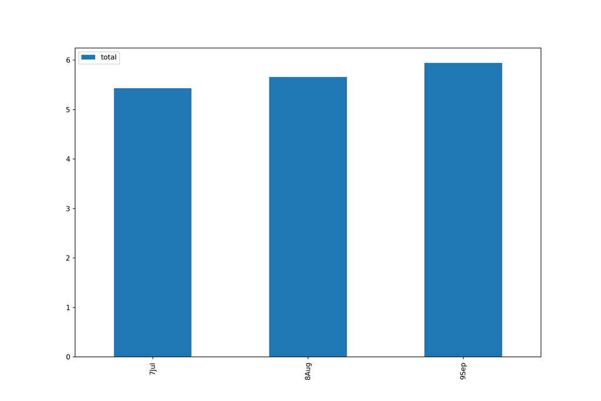

```python
url = 'https://raw.githubusercontent.com/QuanNguyenIU/QuanNguyenIU.github.io/main/DataCamp/Python/Joining%20Data%20with%20Pandas/inv_jul.csv'
inv_jul = pd.read_csv(url)
url = 'https://raw.githubusercontent.com/QuanNguyenIU/QuanNguyenIU.github.io/main/DataCamp/Python/Joining%20Data%20with%20Pandas/inv_aug.csv'
inv_aug = pd.read_csv(url)
url = 'https://raw.githubusercontent.com/QuanNguyenIU/QuanNguyenIU.github.io/main/DataCamp/Python/Joining%20Data%20with%20Pandas/inv_sep.csv'
inv_sep = pd.read_csv(url)

# Concatenate the tables and add keys
inv_jul_thr_sep = pd.concat([inv_jul,inv_aug,inv_sep],
                            keys=['7Jul','8Aug','9Sep'])

# Group the invoices by the index keys and find avg of the total column
avg_inv_by_month = inv_jul_thr_sep.groupby(level=0).agg({'total':'mean'})

# Bar plot of avg_inv_by_month
avg_inv_by_month.plot(kind='bar')
plt.show()
```

Way to come through! There are many ways to write code for this task. However, concatenating the tables with a key provides a hierarchical index that can be used for grouping. Once grouped, you can average the groups and create plots. You were able to find out that September had the highest average invoice total.

## 4.7 Lecture: Verifying integrity

[video not shown]

## 4.8 Concatenate and merge to find common songs

The senior leadership of the streaming service is requesting your help again. You are given the historical files for a popular playlist in the classical music genre in 2018 and 2019. Additionally, you are given a similar set of files for the most popular pop music genre playlist on the streaming service in 2018 and 2019. Your goal is to concatenate the respective files to make a large classical playlist table and overall popular music table. Then filter the classical music table using a semi join to return only the most popular classical music tracks.

The tables [**classic_18**, [**classic_19**, [**pop_18**, and [**pop_19** have been loaded for you.](https://raw.githubusercontent.com/QuanNguyenIU/QuanNguyenIU.github.io/main/DataCamp/Python/Joining%20Data%20with%20Pandas/pop_19.csv)](https://raw.githubusercontent.com/QuanNguyenIU/QuanNguyenIU.github.io/main/DataCamp/Python/Joining%20Data%20with%20Pandas/pop_18.csv)](https://raw.githubusercontent.com/QuanNguyenIU/QuanNguyenIU.github.io/main/DataCamp/Python/Joining%20Data%20with%20Pandas/classic_19.csv)](https://raw.githubusercontent.com/QuanNguyenIU/QuanNguyenIU.github.io/main/DataCamp/Python/Joining%20Data%20with%20Pandas/classic_18.csv)

```python
url = 'https://raw.githubusercontent.com/QuanNguyenIU/QuanNguyenIU.github.io/main/DataCamp/Python/Joining%20Data%20with%20Pandas/classic_18.csv'
classic_18 = pd.read_csv(url)
url = 'https://raw.githubusercontent.com/QuanNguyenIU/QuanNguyenIU.github.io/main/DataCamp/Python/Joining%20Data%20with%20Pandas/classic_19.csv'
classic_19 = pd.read_csv(url)
url = 'https://raw.githubusercontent.com/QuanNguyenIU/QuanNguyenIU.github.io/main/DataCamp/Python/Joining%20Data%20with%20Pandas/pop_18.csv'
pop_18 = pd.read_csv(url)
url = 'https://raw.githubusercontent.com/QuanNguyenIU/QuanNguyenIU.github.io/main/DataCamp/Python/Joining%20Data%20with%20Pandas/pop_19.csv'
pop_19 = pd.read_csv(url)

# Concatenate the classic tables vertically
classic_18_19 = pd.concat([classic_18, classic_19], ignore_index=True)

# Concatenate the pop tables vertically
pop_18_19 = pd.concat([pop_18, pop_19], ignore_index=True)

# Merge classic_18_19 with pop_18_19
classic_pop = classic_18_19.merge(pop_18_19,on='tid')

# Using .isin(), filter classic_18_19 rows where tid is in classic_pop
popular_classic = classic_18_19[classic_18_19['tid'].isin(classic_pop['tid'])]

# Print popular chart
print(popular_classic)
```

```
##     pid   tid
## 3    12  3479
## 10   12  3439
## 21   12  3445
## 23   12  3449
## 48   12  3437
## 50   12  3435
```

You now have experience combining data vertically and using semi- and anti joins. Time to move on to the next chapter!

# 5 Merging Ordered and Time-Series Data

In this final chapter, you’ll step up a gear and learn to apply pandas’ specialized methods for merging time-series and ordered data together with real-world financial and economic data from the city of Chicago. You’ll also learn how to query resulting tables using a SQL-style format, and unpivot data using the melt method.

## 5.1 Lecture: Using merge_ordered()

[video not shown]

## 5.2 Correlation between GDP and S&P500

In this exercise, you want to analyze stock returns from the S&P 500. You believe there may be a relationship between the returns of the S&P 500 and the GDP of the US. Merge the different datasets together to compute the correlation.

Two tables have been provided for you, named [**sp500**, and [**gdp_us_2010**.](https://raw.githubusercontent.com/QuanNguyenIU/QuanNguyenIU.github.io/main/DataCamp/Python/Joining%20Data%20with%20Pandas/gdp_us_2010.csv)](https://raw.githubusercontent.com/QuanNguyenIU/QuanNguyenIU.github.io/main/DataCamp/Python/Joining%20Data%20with%20Pandas/sp500.csv)

```python
url = 'https://raw.githubusercontent.com/QuanNguyenIU/QuanNguyenIU.github.io/main/DataCamp/Python/Joining%20Data%20with%20Pandas/sp500.csv'
sp500 = pd.read_csv(url)
url = 'https://raw.githubusercontent.com/QuanNguyenIU/QuanNguyenIU.github.io/main/DataCamp/Python/Joining%20Data%20with%20Pandas/gdp_us_2010.csv'
gdp_us_2010 = pd.read_csv(url)

# Use merge_ordered() to merge gdp and sp500 on year and date
gdp_sp500 = pd.merge_ordered(gdp_us_2010, sp500, left_on='year', right_on='date',
                             how='left')

# Print gdp_sp500
print(gdp_sp500)
```

```
##   country code  year           gdp    date  returns
## 0          USA  2010  1.499210e+13  2010.0    12.78
## 1          USA  2011  1.554260e+13  2011.0     0.00
## 2          USA  2012  1.619700e+13  2012.0    13.41
## 3          USA  2012  1.619700e+13  2012.0    13.41
## 4          USA  2013  1.678480e+13  2013.0    29.60
## 5          USA  2014  1.752170e+13  2014.0    11.39
## 6          USA  2015  1.821930e+13  2015.0    -0.73
## 7          USA  2016  1.870720e+13  2016.0     9.54
## 8          USA  2017  1.948540e+13  2017.0    19.42
## 9          USA  2018  2.049410e+13     NaN      NaN
```

```python
# Use merge_ordered() to merge gdp and sp500, interpolate missing value
gdp_sp500 = pd.merge_ordered(gdp_us_2010, sp500, left_on='year', right_on='date',
                             how='left',fill_method='ffill')

# Print gdp_sp500
print (gdp_sp500)
```

```
##   country code  year           gdp  date  returns
## 0          USA  2010  1.499210e+13  2010    12.78
## 1          USA  2011  1.554260e+13  2011     0.00
## 2          USA  2012  1.619700e+13  2012    13.41
## 3          USA  2012  1.619700e+13  2012    13.41
## 4          USA  2013  1.678480e+13  2013    29.60
## 5          USA  2014  1.752170e+13  2014    11.39
## 6          USA  2015  1.821930e+13  2015    -0.73
## 7          USA  2016  1.870720e+13  2016     9.54
## 8          USA  2017  1.948540e+13  2017    19.42
## 9          USA  2018  2.049410e+13  2017    19.42
```

```python
# Subset the gdp and returns columns
gdp_returns = gdp_sp500[['gdp','returns']]

# Print gdp_returns correlation
print (gdp_returns.corr())
```

```
##               gdp   returns
## gdp      1.000000  0.212173
## returns  0.212173  1.000000
```

## 5.3 Phillips curve using merge_ordered()

There is an economic theory developed by A. W. Phillips which states that inflation and unemployment have an inverse relationship. The theory claims that with economic growth comes inflation, which in turn should lead to more jobs and less unemployment.

You will take two tables of data from the U.S. Bureau of Labor Statistics, containing unemployment and inflation data over different periods, and create a Phillips curve. The tables have different frequencies. One table has a data entry every six months, while the other has a data entry every month. You will need to use the entries where you have data within both tables.

The tables [**unemployment** and [**inflation** have been loaded for you.](https://raw.githubusercontent.com/QuanNguyenIU/QuanNguyenIU.github.io/main/DataCamp/Python/Joining%20Data%20with%20Pandas/inflation.csv)](https://raw.githubusercontent.com/QuanNguyenIU/QuanNguyenIU.github.io/main/DataCamp/Python/Joining%20Data%20with%20Pandas/unemployment.csv)

```python
url = 'https://raw.githubusercontent.com/QuanNguyenIU/QuanNguyenIU.github.io/main/DataCamp/Python/Joining%20Data%20with%20Pandas/unemployment.csv'
unemployment = pd.read_csv(url)
url = 'https://raw.githubusercontent.com/QuanNguyenIU/QuanNguyenIU.github.io/main/DataCamp/Python/Joining%20Data%20with%20Pandas/inflation.csv'
inflation = pd.read_csv(url)

# Use merge_ordered() to merge inflation, unemployment with inner join
inflation_unemploy = pd.merge_ordered(inflation,unemployment,on='date',how='inner')

# Print inflation_unemploy
print(inflation_unemploy)
```

```
##          date      cpi  ...                  data_type unemployment_rate
## 0  2014-01-01  235.288  ...  SEASONALLY ADJUSTED INDEX               6.7
## 1  2014-06-01  237.231  ...  SEASONALLY ADJUSTED INDEX               6.1
## 2  2015-01-01  234.718  ...  SEASONALLY ADJUSTED INDEX               5.6
## 3  2015-06-01  237.684  ...  SEASONALLY ADJUSTED INDEX               5.3
## 4  2016-01-01  237.833  ...  SEASONALLY ADJUSTED INDEX               5.0
## 5  2016-06-01  240.167  ...  SEASONALLY ADJUSTED INDEX               4.9
## 6  2017-01-01  243.780  ...  SEASONALLY ADJUSTED INDEX               4.7
## 7  2017-06-01  244.182  ...  SEASONALLY ADJUSTED INDEX               4.3
## 8  2018-01-01  248.884  ...  SEASONALLY ADJUSTED INDEX               4.1
## 9  2018-06-01  251.134  ...  SEASONALLY ADJUSTED INDEX               4.0
##
## [10 rows x 5 columns]
```

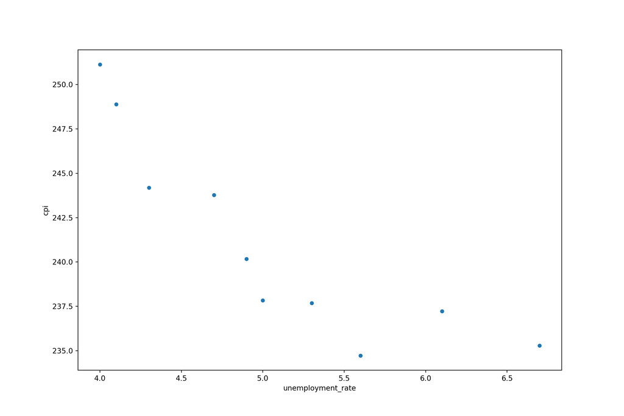

```python
# Plot a scatter plot of unemployment_rate vs cpi of inflation_unemploy
inflation_unemploy.plot(x='unemployment_rate',y='cpi',kind='scatter')
plt.show()
```

Great work! You created a Phillips curve. There are critics of the curve, but what is more important in this example is that you were able to use entries where you had entries in both tables by using an inner join. You might ask why not use the default outer join and use forward fill to fill to estimate the missing variables. You might choose differently. In this case, instead of showing an estimated unemployment rate (which is a continually changing measure) for five periods, that data was dropped from the plot.

## 5.4 merge_ordered() caution, multiple columns

When using merge_ordered() to merge on multiple columns, the order is important when you combine it with the forward fill feature. The function sorts the merge on columns in the order provided. In this exercise, we will merge GDP and population data from the World Bank for Australia and Sweden, reversing the order of the merge on columns. The frequency of the series are different, the GDP values are quarterly, and the population is yearly. Use the forward fill feature to fill in the missing data. Depending on the order provided, the fill forward will use unintended data to fill in the missing values.

The tables [**gdp_aus_swe** and [**pop** have been loaded.](https://raw.githubusercontent.com/QuanNguyenIU/QuanNguyenIU.github.io/main/DataCamp/Python/Joining%20Data%20with%20Pandas/pop.csv)](https://raw.githubusercontent.com/QuanNguyenIU/QuanNguyenIU.github.io/main/DataCamp/Python/Joining%20Data%20with%20Pandas/gdp_aus_swe.csv)

```python
url = 'https://raw.githubusercontent.com/QuanNguyenIU/QuanNguyenIU.github.io/main/DataCamp/Python/Joining%20Data%20with%20Pandas/gdp_aus_swe.csv'
gdp_aus_swe = pd.read_csv(url)
url = 'https://raw.githubusercontent.com/QuanNguyenIU/QuanNguyenIU.github.io/main/DataCamp/Python/Joining%20Data%20with%20Pandas/pop.csv'
pop = pd.read_csv(url)

# Merge gdp and pop on date and country with fill and notice rows 2 and 3
ctry_date = pd.merge_ordered(gdp_aus_swe,pop,on=['date','country'],
                             fill_method='ffill')

# Print ctry_date
print(ctry_date)
```

```
##           date    country           gdp  series_code_x       pop series_code_y
## 0   1990-01-01  Australia  158051.13240  NYGDPMKTPSAKD  17065100   SP.POP.TOTL
## 1   1990-01-01     Sweden   79837.84599  NYGDPMKTPSAKD   8558835   SP.POP.TOTL
## 2   1990-04-01  Australia  158263.58160  NYGDPMKTPSAKD   8558835   SP.POP.TOTL
## 3   1990-04-01     Sweden   80582.28597  NYGDPMKTPSAKD   8558835   SP.POP.TOTL
## 4   1990-07-01  Australia  157329.27900  NYGDPMKTPSAKD   8558835   SP.POP.TOTL
## 5   1990-07-01     Sweden   79974.36017  NYGDPMKTPSAKD   8558835   SP.POP.TOTL
## 6   1990-09-01  Australia  158240.67810  NYGDPMKTPSAKD   8558835   SP.POP.TOTL
## 7   1990-09-01     Sweden   80106.49738  NYGDPMKTPSAKD   8558835   SP.POP.TOTL
## 8   1991-01-01  Australia  156195.95350  NYGDPMKTPSAKD  17284000   SP.POP.TOTL
## 9   1991-01-01     Sweden   79524.24192  NYGDPMKTPSAKD   8617375   SP.POP.TOTL
## 10  1991-04-01  Australia  155989.03270  NYGDPMKTPSAKD   8617375   SP.POP.TOTL
## 11  1991-04-01     Sweden   79073.05901  NYGDPMKTPSAKD   8617375   SP.POP.TOTL
## 12  1991-07-01  Australia  156635.85760  NYGDPMKTPSAKD   8617375   SP.POP.TOTL
## 13  1991-07-01     Sweden   79084.77036  NYGDPMKTPSAKD   8617375   SP.POP.TOTL
```

[output cut: 18 more lines]

```python
# Merge gdp and pop on country and date with fill
date_ctry = pd.merge_ordered(gdp_aus_swe,pop,on=['country','date'],
                             fill_method='ffill')

# Print date_ctry
print(date_ctry)
```

```
##           date    country           gdp  series_code_x       pop series_code_y
## 0   1990-01-01  Australia  158051.13240  NYGDPMKTPSAKD  17065100   SP.POP.TOTL
## 1   1990-04-01  Australia  158263.58160  NYGDPMKTPSAKD  17065100   SP.POP.TOTL
## 2   1990-07-01  Australia  157329.27900  NYGDPMKTPSAKD  17065100   SP.POP.TOTL
## 3   1990-09-01  Australia  158240.67810  NYGDPMKTPSAKD  17065100   SP.POP.TOTL
## 4   1991-01-01  Australia  156195.95350  NYGDPMKTPSAKD  17284000   SP.POP.TOTL
## 5   1991-04-01  Australia  155989.03270  NYGDPMKTPSAKD  17284000   SP.POP.TOTL
## 6   1991-07-01  Australia  156635.85760  NYGDPMKTPSAKD  17284000   SP.POP.TOTL
## 7   1991-09-01  Australia  156744.05660  NYGDPMKTPSAKD  17284000   SP.POP.TOTL
## 8   1992-01-01  Australia  157916.08110  NYGDPMKTPSAKD  17495000   SP.POP.TOTL
## 9   1992-04-01  Australia  159047.82710  NYGDPMKTPSAKD  17495000   SP.POP.TOTL
## 10  1992-07-01  Australia  160658.17600  NYGDPMKTPSAKD  17495000   SP.POP.TOTL
## 11  1992-09-01  Australia  163960.22070  NYGDPMKTPSAKD  17495000   SP.POP.TOTL
## 12  1993-01-01  Australia  165097.49510  NYGDPMKTPSAKD  17667000   SP.POP.TOTL
## 13  1993-04-01  Australia  166027.05900  NYGDPMKTPSAKD  17667000   SP.POP.TOTL
```

[output cut: 18 more lines]

Nice! When you merge on date first, the table is sorted by date then country. When forward fill is applied, Sweden’s population value in January is used to fill in the missing values for both Australia and Sweden for the remainder of the year. This is not what you want. The fill forward is using unintended data to fill in the missing values. However, when you merge on country first, the table is sorted by country then date, so the forward fill is applied appropriately in this situation.

## 5.5 Lecture: Using merge_asof()

[video not shown]

## 5.6 Using merge_asof() to study stocks

You have a feed of stock market prices that you record. You attempt to track the price every five minutes. Still, due to some network latency, the prices you record are roughly every 5 minutes. You pull your price logs for three banks, JP Morgan (JPM), Wells Fargo (WFC), and Bank Of America (BAC). You want to know how the price change of the two other banks compare to JP Morgan. Therefore, you will need to merge these three logs into one table. Afterward, you will use the pandas .diff() method to compute the price change over time. Finally, plot the price changes so you can review your analysis.

The three log files have been loaded for you as tables named [**jpm**, [**wells**, and [**bac**.](https://raw.githubusercontent.com/QuanNguyenIU/QuanNguyenIU.github.io/main/DataCamp/Python/Joining%20Data%20with%20Pandas/bac.csv)](https://raw.githubusercontent.com/QuanNguyenIU/QuanNguyenIU.github.io/main/DataCamp/Python/Joining%20Data%20with%20Pandas/wells.csv)](https://raw.githubusercontent.com/QuanNguyenIU/QuanNguyenIU.github.io/main/DataCamp/Python/Joining%20Data%20with%20Pandas/jpm.csv)

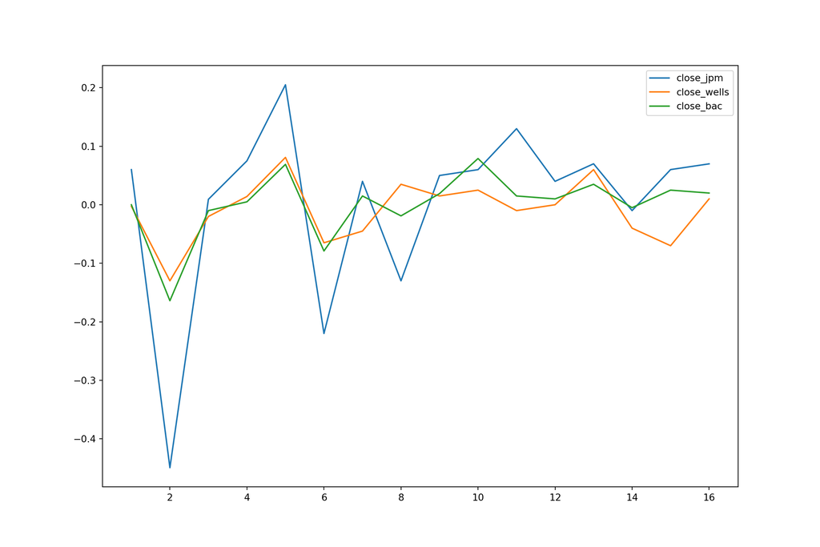

```python
url = 'https://raw.githubusercontent.com/QuanNguyenIU/QuanNguyenIU.github.io/main/DataCamp/Python/Joining%20Data%20with%20Pandas/jpm.csv'
jpm = pd.read_csv(url)
url = 'https://raw.githubusercontent.com/QuanNguyenIU/QuanNguyenIU.github.io/main/DataCamp/Python/Joining%20Data%20with%20Pandas/wells.csv'
wells = pd.read_csv(url)
url = 'https://raw.githubusercontent.com/QuanNguyenIU/QuanNguyenIU.github.io/main/DataCamp/Python/Joining%20Data%20with%20Pandas/bac.csv'
bac = pd.read_csv(url)

jpm['date_time'] = pd.to_datetime(jpm['date_time'])
wells['date_time'] = pd.to_datetime(wells['date_time'])
bac['date_time'] = pd.to_datetime(bac['date_time'])

# Use merge_asof() to merge jpm and wells
jpm_wells = pd.merge_asof(jpm, wells, on = 'date_time', suffixes=('', '_wells'), direction='nearest')


# Use merge_asof() to merge jpm_wells and bac
jpm_wells_bac = pd.merge_asof(jpm_wells, bac, on = 'date_time', suffixes=('_jpm', '_bac'),direction='nearest')


# Compute price diff
price_diffs = jpm_wells_bac.diff()

# Plot the price diff of the close of jpm, wells and bac only
price_diffs.plot(y=['close_jpm', 'close_wells', 'close_bac'])
plt.show()
```

Fabulous! You can see that during this period, the price change for these bank stocks was roughly the same, although the price change for *JP Morgan* was more variable. The critical point here is that the merge_asof() function is very useful in performing the fuzzy matching between the timestamps of all the tables.

## 5.7 Using merge_asof() to create dataset

The merge_asof() function can be used to create datasets where you have a table of start and stop dates, and you want to use them to create a flag in another table. You have been given gdp, which is a table of quarterly GDP values of the US during the 1980s. Additionally, the table recession has been given to you. It holds the starting date of every US recession since 1980, and the date when the recession was declared to be over. Use merge_asof() to merge the tables and create a status flag if a quarter was during a recession. Finally, to check your work, plot the data in a bar chart.

The tables [**gdp_us_1979** and [**recession** have been loaded for you.](https://raw.githubusercontent.com/QuanNguyenIU/QuanNguyenIU.github.io/main/DataCamp/Python/Joining%20Data%20with%20Pandas/recession.csv)](https://raw.githubusercontent.com/QuanNguyenIU/QuanNguyenIU.github.io/main/DataCamp/Python/Joining%20Data%20with%20Pandas/gdp_us_1979.csv)

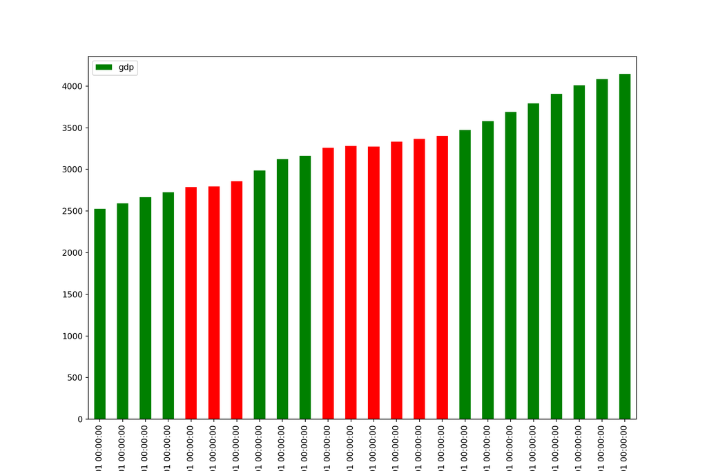

```python
url = 'https://raw.githubusercontent.com/QuanNguyenIU/QuanNguyenIU.github.io/main/DataCamp/Python/Joining%20Data%20with%20Pandas/gdp_us_1979.csv'
gdp_us_1979 = pd.read_csv(url)
url = 'https://raw.githubusercontent.com/QuanNguyenIU/QuanNguyenIU.github.io/main/DataCamp/Python/Joining%20Data%20with%20Pandas/recession.csv'
recession = pd.read_csv(url)

gdp_us_1979['date'] = pd.to_datetime(gdp_us_1979['date'])
recession['date'] = pd.to_datetime(recession['date'])

# Merge gdp and recession on date using merge_asof()
gdp_recession = pd.merge_asof(gdp_us_1979,recession,on='date')

# Create a list based on the row value of gdp_recession['econ_status']
is_recession = ['r' if s=='recession' else 'g' for s in gdp_recession['econ_status']]

# Plot a bar chart of gdp_recession
gdp_recession.plot(kind='bar', y='gdp', x='date', color=is_recession, rot=90)
plt.show()
```

Terrific work! You can see from the chart that there were a number of quarters early in the 1980s where a recession was an issue. merge_asof() allowed you to quickly add a flag to the gdp dataset by matching between two different dates, in one line of code! If you were to perform the same task using subsetting, it would have taken a lot more code.

## 5.8 Lecture: Selecting data with .query()

[video not shown]

## 5.9 Subsetting rows with .query()

In this exercise, you will revisit GDP and population data for Australia and Sweden from the World Bank and expand on it using the .query() method. You’ll merge the two tables and compute the GDP per capita. Afterwards, you’ll use the .query() method to sub-select the rows and create a plot. Recall that you will need to merge on multiple columns in the proper order.

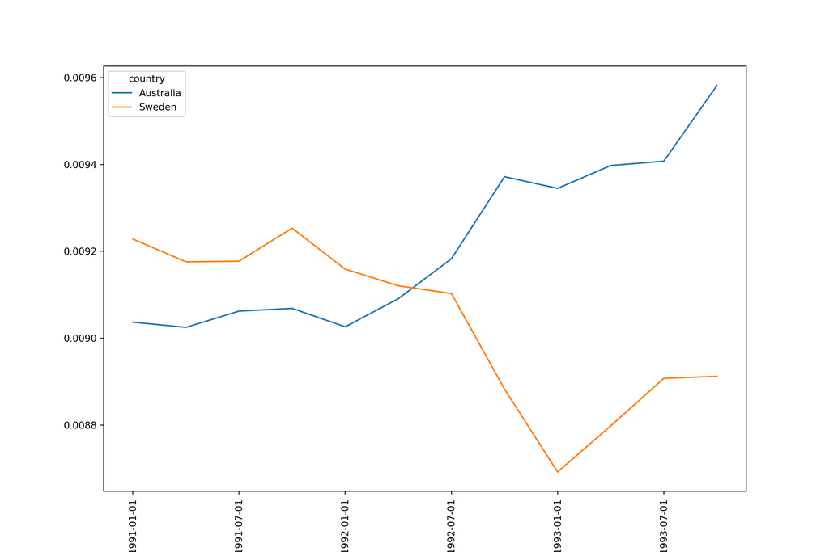

```python
# Merge gdp and pop on date and country with fill
gdp_pop = pd.merge_ordered(gdp_aus_swe, pop, on=['country','date'], fill_method='ffill')

# Add a column named gdp_per_capita to gdp_pop that divides the gdp by pop
gdp_pop['gdp_per_capita'] = gdp_pop['gdp'] / gdp_pop['pop']

# Pivot data so gdp_per_capita, where index is date and columns is country
gdp_pivot = gdp_pop.pivot_table('gdp_per_capita', 'date', 'country')

# Select dates equal to or greater than 1991-01-01
recent_gdp_pop = gdp_pivot.query('date >= "1991-01-01"')

# Plot recent_gdp_pop
recent_gdp_pop.plot(rot=90)
plt.show()
```

Amazing! You can see from the plot that the per capita GDP of Australia passed Sweden in 1992. By using the .query() method, you were able to select the appropriate rows easily. The .query() method is easy to read and straightforward.

## 5.10 Lecture: Reshaping data with .melt()

[video not shown]

## 5.11 Using .melt() to reshape government data

The US Bureau of Labor Statistics (BLS) often provides data series in an easy-to-read format - it has a separate column for each month, and each year is a different row. Unfortunately, this wide format makes it difficult to plot this information over time. In this exercise, you will reshape a table of US unemployment rate data from the BLS into a form you can plot using .melt(). You will need to add a date column to the table and sort by it to plot the data correctly.

The unemployment rate data has been loaded for you in a table called [**ur_wide**.](https://raw.githubusercontent.com/QuanNguyenIU/QuanNguyenIU.github.io/main/DataCamp/Python/Joining%20Data%20with%20Pandas/ur_wide.csv)

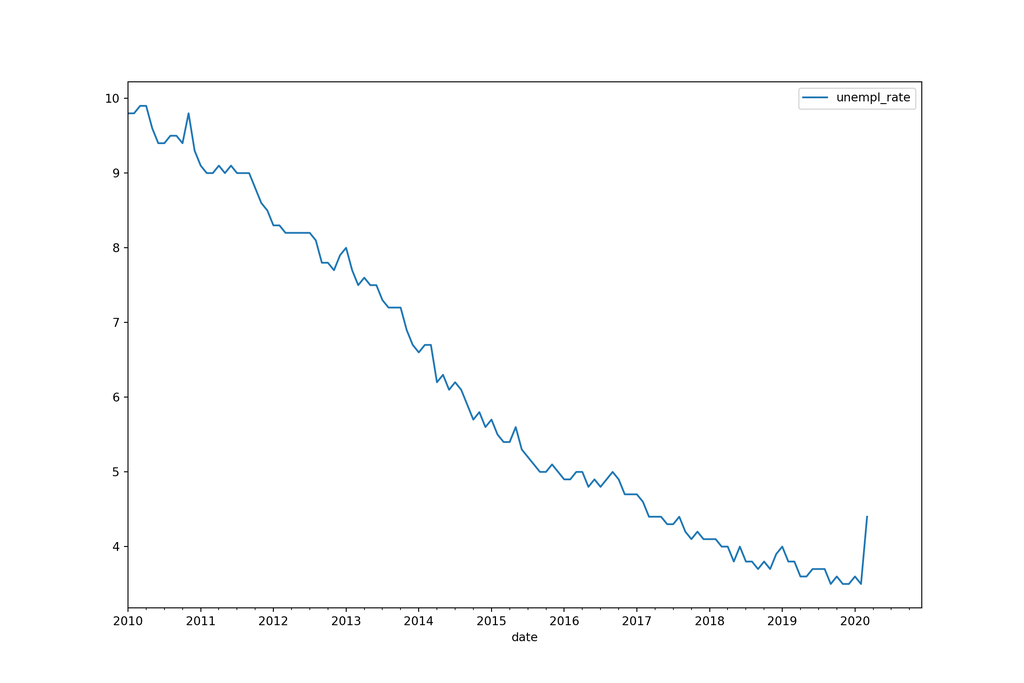

```python
url = 'https://raw.githubusercontent.com/QuanNguyenIU/QuanNguyenIU.github.io/main/DataCamp/Python/Joining%20Data%20with%20Pandas/ur_wide.csv'
ur_wide = pd.read_csv(url)

# unpivot everything besides the year column
ur_tall = ur_wide.melt(id_vars = ['year'], var_name = 'month',value_name='unempl_rate')


# Create a date column using the month and year columns of ur_tall
ur_tall['date'] = pd.to_datetime(ur_tall['year'].astype(str) + '-' + ur_tall['month'])

# Sort ur_tall by date in ascending order
ur_sorted = ur_tall.sort_values('date')

# Plot the unempl_rate by date
ur_sorted.plot(x='date',y='unempl_rate')
plt.show()
```

Nice going! The plot shows a steady decrease in the unemployment rate with an increase near the end. This increase is likely the effect of the COVID-19 pandemic and its impact on shutting down most of the US economy. In general, data is often provided (*especially by governments*) in a format that is easily read by people but not by machines. The .melt() method is a handy tool for reshaping data into a useful form.

## 5.12 Using .melt() for stocks vs bond performance

It is widespread knowledge that the price of bonds is inversely related to the price of stocks. In this last exercise, you’ll review many of the topics in this chapter to confirm this. You have been given a table of percent change of the US 10-year treasury bond price. It is in a wide format where there is a separate column for each year. You will need to use the .melt() method to reshape this table.

Additionally, you will use the .query() method to filter out unneeded data. You will merge this table with a table of the percent change of the Dow Jones Industrial stock index price. Finally, you will plot data.

The tables [**ten_yr** and [**dji** have been loaded for you.](https://raw.githubusercontent.com/QuanNguyenIU/QuanNguyenIU.github.io/main/DataCamp/Python/Joining%20Data%20with%20Pandas/dji.csv)](https://raw.githubusercontent.com/QuanNguyenIU/QuanNguyenIU.github.io/main/DataCamp/Python/Joining%20Data%20with%20Pandas/ten_yr.csv)

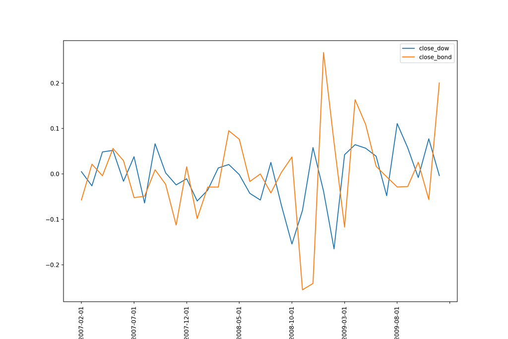

```python
url = 'https://raw.githubusercontent.com/QuanNguyenIU/QuanNguyenIU.github.io/main/DataCamp/Python/Joining%20Data%20with%20Pandas/ten_yr.csv'
ten_yr = pd.read_csv(url)
url = 'https://raw.githubusercontent.com/QuanNguyenIU/QuanNguyenIU.github.io/main/DataCamp/Python/Joining%20Data%20with%20Pandas/dji.csv'
dji = pd.read_csv(url)

# Use melt on ten_yr, unpivot everything besides the metric column
bond_perc = ten_yr.melt(id_vars=['metric'],var_name='date',value_name='close')

# Use query on bond_perc to select only the rows where metric=close
bond_perc_close = bond_perc.query('metric == "close"')

# Merge (ordered) dji and bond_perc_close on date with an inner join
dow_bond = pd.merge_ordered(dji,bond_perc_close,on='date',how='inner',suffixes=('_dow', '_bond'))


# Plot only the close_dow and close_bond columns
dow_bond.plot(y=['close_dow','close_bond'], x='date', rot=90)
plt.show()
```

Super job! You used many of the techniques we have reviewed in this chapter to produce the plot. The plot confirms that the bond and stock prices are inversely correlated. Often as the price of stocks increases, the price for bonds decreases.

# 6 Course Recap

[video not shown]

Congratulations on completing the course! More courses, tracks and instructions can be found [**here**. Happy learning!](https://quannguyeniu.github.io/DataCamp/master.html)